# Capstone - Movie Ratings Prediction

05 November 2021

```r
knitr::opts_chunk$set(echo = TRUE,
                      warning = FALSE,
                      message = FALSE)
```

# Executive Summary

This is a capstone project for [HarvardX Data Science - Professional Certificate](http://rmarkdown.rstudio.com) program. Objective of project is to create a move recommendation system using MovieLens dataset, using all tools (in particular ML algorithms) shown throught-out the HarvardX DS program.

## Dataset

Data assigned for this project is the 10 million ratings version of the [MovieLens dataset](https://grouplens.org/datasets/movielens/10m/). There are 72K users in this dataset. The dataset is created as follows:

# Data Prep - Extract, transform, load train and validation set.

```r
movielens <- left_join(ratings, movies, by = "movieId")

# data transformation - cleaning
# UTC timestamp into date, identify movie release year
movielens <- movielens %>%
  mutate(rating_timedate = as_datetime(timestamp)) %>%
  mutate(rating_date = date(as_datetime(timestamp))) %>%
  mutate(rating_hour = hour(as_datetime(timestamp))) %>%
  mutate(release_yr = parse_number(str_sub(title, -6, -1))) %>%
  mutate(title = str_trim(str_sub(title, 1, -7))) %>%
  select(-timestamp)

# Validation set will be 10% of MovieLens data
set.seed(1, sample.kind="Rounding") # if using R 3.5 or earlier, use `set.seed(1)`
test_index <- createDataPartition(y = movielens$rating, times = 1, p = 0.1, list = FALSE)
edx <- movielens[-test_index,]
temp <- movielens[test_index,]

# Make sure userId and movieId in validation set are also in edx set
validation <- temp %>%
  semi_join(edx, by = "movieId") %>%
  semi_join(edx, by = "userId")

# Add rows removed from validation set back into edx set
removed <- anti_join(temp, validation)
edx <- rbind(edx, removed)
```

#### Data familiarization

```r
rows <- dim(edx)[1]
cols <- dim(edx)[2]
```

#### Exploratory Data Analysis

##### Rating Distribution

```r
rft <- descr::freq(as.factor(edx$rating), plot = FALSE)
zero_rating <- edx %>% filter(rating == 0) %>%
  nrow()
three_rating <- edx %>% filter(rating == 3) %>%
  nrow()
kable(rft)
```

[output not shown]

No. of ratings given zero = 0. No. of ratings given three = 2121240. Top 4 most given ratings in order from most to least - 4, 3, 5, 3.5, 2-; and Half star (.5) ratings are less common than whole stars.

```r
library(scales)
x <- seq(0, 5, 0.5)
edx %>% ggplot(aes(x = rating)) +
  geom_histogram(binwidth = 0.5, alpha=0.9) +
  stat_bin(binwidth = 0.5, geom ="text", aes(label = ..count..), vjust = -1.5) +
  theme_classic() +
  scale_y_continuous(label = label_number_si(), limits = c(0, 3e6)) +
  scale_x_continuous(labels = as.character(x) ,breaks = x)
```

[output not shown]

No. of distinct movies rated = 10677.

```r
n_movies <- n_distinct(edx$movieId)
n_movies
```

No. of distinct movies by rating

```r
edx %>% group_by(rating) %>% summarize(n_mov = n_distinct(movieId)) %>%
  ggplot(aes(x = rating, y = n_mov)) +
  geom_bar(stat = "identity") +
  geom_text(aes(label= n_mov, vjust = -1.5)) +
  ylim(0, 12500) +
  scale_x_continuous(labels = as.character(x) ,breaks = x) +
  ylab("no of movies") +
  theme_classic()
```

[output not shown]

No. of unique users = 69878.

```r
n_users <- n_distinct(edx$userId)
n_users
```

No. of distinct users by rating

```r
edx %>% group_by(rating) %>% summarize(n_user = n_distinct(userId)) %>%
  ggplot(aes(x = rating, y = n_user)) +
  geom_bar(stat = "identity") +
  geom_text(aes(label= n_user, vjust = -1.5)) +
  scale_y_continuous(labels = label_number_si(), limits = c(0, 80000)) +
  scale_x_continuous(labels = as.character(x) ,breaks = x) +
  ylab("no of users") +
  theme_classic()
```

[output not shown]

Genre stats No. of unique genre combinations

```r
n_genres_combo <- n_distinct(edx$genres)
n_genres_combo
```

```r
n_drama <- edx %>% filter(str_detect(edx$genres, "Drama") == TRUE) %>% summarize(n = n())

#starttime <- Sys.time()

#genre_tab <- edx[,c(1:2,6)] %>% separate_rows(genres, sep = "\\|") %>%
  #group_by(genres) %>%
  #summarize(n_movies = n_distinct(movieId), n_ratings = n(),
            #n_users = n_distinct(userId))
#endtime <- Sys.time()

#duration <- endtime - starttime
#duration #18.7mins
#is there a faster way? need to extract full list of genres follower by str_detect and sum.

kable(arrange(genre_tab, desc(n_movies),
              desc(n_ratings),
              desc(n_users)),
      format = "html",
      caption = "Table 1.1 ") %>%
  kable_styling()

genre_prop_tab <- genre_tab %>%
  mutate(n_mov_prop = round(n_movies/sum(n_movies)*100, 1)) %>%
  mutate(n_rat_prop = round(n_ratings/sum(n_ratings)*100, 1)) %>%
  mutate(n_users_prop = round(n_users/sum(n_users)*100, 1)) %>%
  select(n_mov_prop, n_rat_prop, n_users_prop)
genre_prop_tab %>% kable(arrange(genre_tab, desc(n_mov_prop),
              desc(n_rat_prop),
              desc(n_users_prop)),
      format = "html",
      caption = "Table 1.2",
      col.names = c("Genre", "% Freq Movies", "%Freq Ratings",
                    "%Freq Users")) %>%
  kable_styling()
```

[output not shown]

No. of movie ratings for Drama genre is

| n |
| --- |
| 3910127 |

.

```r
#find out which movies are IMAX and no genre
```

```r
p <- genre_tab %>% ggplot(aes(x = reorder(genres, -n_movies), y = n_movies)) +
  geom_bar(stat = "identity")
p <- p +
  labs(x = "genres",
       y = "# of movies") +
  coord_flip() +
  theme_classic() #most common genre is Drama
p + geom_text(aes(label = n_movies), vjust = 0, hjust = -0.5) +
  ylim(c(0, 6000))
```

[output not shown]

```r
p2 <- edx %>% group_by(genres) %>%
  summarize(n_movies = n_distinct(movieId)) %>%
  filter(n_movies > 100) %>%
  ggplot(aes(x = reorder(genres, -n_movies), y = n_movies)) +
  geom_bar(stat = "identity") +
  geom_text(aes(label = n_movies), hjust = -0.5) +
  ylim(c(0,2000))
p2 <- p2 + coord_flip() +
  theme_classic() +
  labs(y = "# of movies",
       x = "genres")
p2
```

[output not shown]

```r
title_freqtab <- edx %>% group_by(title) %>% summarise(n = n()) %>% arrange(desc(n)) %>% head(50)
title_freqtab

movie_titles <- c("Forrest Gump", "Jurassic Park", "Pulp Fiction",
                  "The Shawshank Redemptioin",
                  "Speed 2: Cruise Control")

edx %>% filter(title %in% movie_titles) %>%
  group_by(title) %>%
  summarize(count = n()) %>% arrange(desc(count))
```

[output not shown]

## Movie Rating Prediction

[output not shown]

set using RMSE

### Method/Analysis

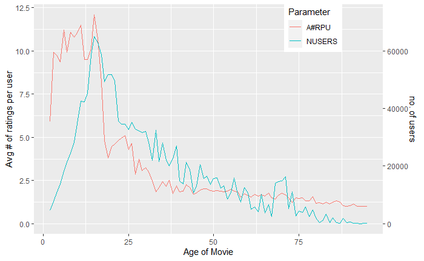